# HW2_key

```r
library(rethinking)
d <- read.csv('https://mcmahanp.github.io/soci620/data/dev_and_col.csv')
d <- d[!is.na(d$latest_gini) & !is.na(d$colonized),]
d
```

[output not shown]

|  | country_name | country_code | latest_gini | latest_gini_year | population_2015 | population_growth_2015 | population_density_2015 | population_pct_urban_2015 | population_pct_immigrant_2015 | gdp_usd2010_2015 | gdp_percap_usd2010_2015 | fertility_rate_2015 | independence_year | independece_from | independence_violent | colonized | primary_colonial_ruler |
| --- | --- | --- | --- | --- | --- | --- | --- | --- | --- | --- | --- | --- | --- | --- | --- | --- | --- |
| 2 | Albania | ALB | 29.0 | 2012 | 2880703 | -0.2912058 | 105.135146 | 57.434 | 1.9890364 | 1.303416e+10 | 4524.6444 | 1.714 | 1913 | Turkey | 1 | 1 | Turkey |
| 3 | Algeria | DZA | 27.6 | 2011 | 39871528 | 1.9199590 | 16.740504 | 70.848 | 0.6110720 | 1.897723e+11 | 4759.5952 | 2.839 | 1962 | France | 1 | 1 | France |
| 6 | Angola | AGO | 42.7 | 2008 | 27859305 | 3.4280207 | 22.346439 | 63.446 | 0.4270047 | 1.038874e+11 | 3729.0035 | 5.766 | 1975 | Portugal | 1 | 1 | Portugal |
| 8 | Argentina | ARG | 42.4 | 2016 | 43417765 | 1.0098550 | 15.865065 | 91.503 | 4.8052923 | 4.558254e+11 | 10498.5925 | 2.308 | 1816 | Spain | 1 | 1 | Spain |
| 9 | Armenia | ARM | 32.5 | 2016 | 2916950 | 0.3685282 | 102.456972 | 63.085 | 6.3358929 | 1.147904e+10 | 3935.2888 | 1.622 | 1991 | Russian Federation | 0 | 0 | Turkey |
| 11 | Australia | AUS | 34.7 | 2010 | 23850784 | 1.4640598 | 3.104641 | 85.701 | 28.2184097 | 1.312204e+12 | 55017.2480 | 1.809 | 1901 | United Kingdom | 0 | 0 | United Kingdom |
| 12 | Austria | AUT | 30.5 | 2015 | 8642699 | 1.1209925 | 104.730790 | 57.715 | 17.4657263 | 4.140332e+11 | 47905.5432 | 1.490 | 1918 | Austria-Hungary | 1 | 0 | NA |
| 13 | Azerbaijan | AZE | 16.6 | 2005 | 9649341 | 1.1912099 | 116.731077 | 54.714 | 2.7090616 | 5.902532e+10 | 6117.0309 | 1.940 | 1991 | Russian Federation | 0 | 0 | Russian Federation |
| 16 | Bangladesh | BGD | 32.4 | 2016 | 161200886 | 1.1201443 | 1238.387386 | 34.308 | 0.8837537 | 1.566295e+11 | 971.6420 | 2.133 | 1971 | Pakistan | 1 | 0 | United Kingdom |
| 18 | Belarus | BLR | 27.0 | 2016 | 9489616 | 0.1593008 | 46.767611 | 77.181 | 11.4040106 | 6.072111e+10 | 6398.6897 | 1.724 | 1991 | Russian Federation | 0 | 0 | Russian Federation |
| 19 | Belgium | BEL | 27.7 | 2015 | 11274196 | 0.5794462 | 372.331440 | 97.876 | 12.2835332 | 5.079292e+11 | 45052.3653 | 1.700 | 1830 | Netherlands | 1 | 0 | Netherlands |
| 21 | Benin | BEN | 47.8 | 2015 | 10575952 | 2.7729779 | 93.791699 | 45.695 | 2.2555410 | 8.755148e+09 | 827.8355 | 5.048 | 1960 | France | 0 | 1 | France |
| 23 | Bhutan | BTN | 37.4 | 2017 | 787386 | 1.3988925 | 20.657082 | 38.678 | 6.5957694 | 2.069400e+09 | 2628.1896 | 2.086 | 1947 | India | 0 | 1 | United Kingdom |
| 24 | Bolivia | BOL | 44.6 | 2016 | 10724705 | 1.5272250 | 9.900032 | 68.393 | 1.3332674 | 2.566405e+10 | 2392.9840 | 2.921 | 1825 | Spain | 1 | 1 | Spain |
| 25 | Bosnia and Herzegovina | BIH | 32.7 | 2015 | 3535961 | -0.8459965 | 69.061738 | 47.173 | 0.9133648 | 1.835268e+10 | 5190.2938 | 1.345 | 1992 | Serbia | 1 | 0 | Turkey |
| 26 | Botswana | BWA | 60.5 | 2009 | 2209197 | 1.8559754 | 3.898147 | 67.155 | 7.1003344 | 1.614649e+10 | 7308.7606 | 2.774 | 1966 | United Kingdom | 0 | 1 | United Kingdom |
| 27 | Brazil | BRA | 51.3 | 2015 | 205962108 | 0.8527992 | 24.642098 | 85.770 | 0.3433132 | 2.337992e+12 | 11351.5657 | 1.740 | 1822 | Portugal | 0 | 1 | Portugal |
| 30 | Bulgaria | BGR | 37.4 | 2014 | 7177991 | -0.6380695 | 66.120035 | 73.990 | 1.4281964 | 5.463903e+10 | 7612.0224 | 1.530 | 1878 | Turkey | 1 | 1 | Turkey |
| 31 | Burkina Faso | BFA | 35.3 | 2014 | 18110624 | 2.9396904 | 66.193801 | 27.530 | 3.8920399 | 1.168805e+10 | 645.3699 | 5.436 | 1960 | France | 0 | 1 | France |
| 32 | Burundi | BDI | 38.6 | 2013 | 10199270 | 3.0611029 | 397.167835 | 12.078 | 2.5656322 | 2.310421e+09 | 226.5281 | 5.781 | 1962 | Belgium | 0 | 1 | Belgium |
| 33 | Cabo Verde | CPV | 47.2 | 2007 | 532913 | 1.2226518 | 132.236476 | 64.300 | 2.8672320 | 1.791765e+09 | 3362.2100 | 2.374 | 1975 | Portugal | 0 | 1 | Portugal |
| 35 | Cameroon | CMR | 46.6 | 2014 | 22834522 | 2.6385361 | 48.305562 | 54.578 | 1.6363137 | 3.355848e+10 | 1469.6377 | 4.778 | 1960 | France | 1 | 1 | France |
| 36 | Canada | CAN | 34.0 | 2013 | 35832513 | 0.8327746 | 3.940449 | 81.259 | 21.8016636 | 1.802513e+12 | 50303.8368 | 1.600 | 1867 | United Kingdom | 0 | 1 | United Kingdom |
| 38 | Central African Republic | CAF | 56.2 | 2008 | 4546100 | 0.6777718 | 7.297345 | 40.277 | 1.6651722 | 1.431688e+09 | 314.9267 | 4.940 | 1960 | France | 0 | 1 | France |
| 39 | Chad | TCD | 43.3 | 2011 | 14009413 | 3.1909403 | 11.125646 | 22.515 | 3.6827714 | 1.348624e+10 | 962.6559 | 6.050 | 1960 | France | 0 | 1 | France |
| 41 | Chile | CHL | 47.7 | 2015 | 17762681 | 0.8417111 | 23.889599 | 87.360 | 2.6155132 | 2.645553e+11 | 14893.8807 | 1.785 | 1818 | Spain | 1 | 1 | Spain |
| 42 | China | CHN | 42.2 | 2012 | 1371220000 | 0.5081367 | 146.057646 | 55.500 | 0.0710764 | 8.908301e+12 | 6496.6240 | 1.617 | 1368 | NA | 1 | 0 | NA |
| 43 | Colombia | COL | 50.8 | 2016 | 48228697 | 0.9097818 | 43.468857 | 79.764 | 0.2760472 | 3.591197e+11 | 7446.1824 | 1.874 | 1819 | Spain | 1 | 1 | Spain |
| 44 | Comoros | COM | 45.3 | 2013 | 777424 | 2.3476995 | 417.745298 | 28.470 | 1.5923163 | 5.982102e+08 | 769.4774 | 4.420 | 1975 | France | 0 | 1 | France |
| 45 | Congo, Dem. Rep. | COD | 42.1 | 2012 | 76196619 | 3.3004164 | 33.610471 | 42.740 | 0.7062463 | 3.133808e+10 | 411.2791 | 6.202 | 1960 | France | 0 | 1 | France |
| ⋮ | ⋮ | ⋮ | ⋮ | ⋮ | ⋮ | ⋮ | ⋮ | ⋮ | ⋮ | ⋮ | ⋮ | ⋮ | ⋮ | ⋮ | ⋮ | ⋮ | ⋮ |
| 176 | Solomon Islands | SLB | 37.1 | 2013 | 587482 | 2.05994286 | 20.98900 | 22.360 | 0.44294720 | 8.707603e+08 | 1482.1906 | 3.9070 | 1978 | United Kingdom | 0 | 1 | United Kingdom |
| 178 | South Africa | ZAF | 63.0 | 2014 | 55291225 | 1.36877044 | 45.57883 | 64.828 | 5.76709045 | 4.188407e+11 | 7575.1748 | 2.4850 | 1910 | United Kingdom | 0 | 1 | United Kingdom |
| 179 | South Sudan | SSD | 46.3 | 2009 | 11882136 | 2.99995499 | NA | 18.852 | 6.67856204 | NA | NA | 4.9380 | 2011 | Sudan | 1 | 0 | United Kingdom |
| 180 | Spain | ESP | 36.2 | 2015 | 46444832 | -0.07758886 | 92.84621 | 79.602 | 12.69023719 | 1.418075e+12 | 30532.4500 | 1.3300 | 1479 | NA | 1 | 0 | NA |
| 181 | Sri Lanka | LKA | 39.8 | 2016 | 20966000 | 0.93442949 | 334.33264 | 18.256 | 0.18685002 | 7.648888e+10 | 3648.2345 | 2.0630 | 1948 | United Kingdom | 0 | 1 | United Kingdom |
| 186 | Sudan | SDN | 35.4 | 2009 | 38647803 | 2.38246910 | 22.12740 | 33.894 | 1.25134454 | 7.273112e+10 | 1881.8953 | 4.5950 | 1956 | United Kingdom | 0 | 1 | United Kingdom |
| 188 | Sweden | SWE | 29.2 | 2015 | 9799186 | 1.05745469 | 24.05830 | 86.553 | 16.76755875 | 5.428265e+11 | 55395.0587 | 1.8500 | 1523 | NA | 1 | 0 | NA |
| 189 | Switzerland | CHE | 32.3 | 2015 | 8282396 | 1.13833715 | 209.59601 | 73.718 | 29.38668554 | 6.333752e+11 | 76472.4595 | 1.5400 | 1291 | NA | 0 | 0 | NA |
| 190 | Syrian Arab Republic | SYR | 35.8 | 2004 | 18734987 | -2.46784652 | 102.02574 | 52.168 | 4.73013439 | NA | NA | 2.9660 | 1946 | France | 1 | 1 | Turkey |
| 191 | Tajikistan | TJK | 34.0 | 2015 | 8548651 | 2.19867702 | 61.59592 | 26.742 | 3.24291090 | 7.912816e+09 | 925.6216 | 3.4040 | 1991 | Russian Federation | 0 | 0 | Russian Federation |
| 192 | Tanzania | TZA | 37.8 | 2011 | 53879957 | 3.10082931 | 60.82632 | 31.617 | 0.48853553 | 4.372822e+10 | 811.5860 | 5.0790 | 1961 | United Kingdom | 0 | 1 | United Kingdom |
| 193 | Thailand | THA | 36.0 | 2015 | 68657600 | 0.35138333 | 134.38822 | 47.694 | 5.75823265 | 3.940783e+11 | 5739.7627 | 1.4980 | 1769 | NA | 1 | 0 | NA |
| 194 | Timor-Leste | TLS | 28.7 | 2014 | 1240977 | 2.29556932 | 83.45508 | 29.490 | 0.91444295 | 3.734284e+09 | 3009.1488 | 5.6180 | 2002 | Indonesia | 1 | 1 | Portugal |
| 195 | Togo | TGO | 43.1 | 2015 | 7416802 | 2.56590112 | 136.36334 | 40.100 | 3.79000676 | 4.046443e+09 | 545.5779 | 4.5170 | 1960 | France | 0 | 1 | France |
| 196 | Tonga | TON | 37.5 | 2009 | 106364 | 0.54868012 | 147.72778 | 23.275 | 5.39794669 | 3.929578e+08 | 3694.4624 | 3.6780 | 1970 | United Kingdom | 0 | 1 | United Kingdom |
| 198 | Tunisia | TUN | 35.8 | 2010 | 11273661 | 1.15761391 | 72.56476 | 68.056 | 0.50384972 | 4.814839e+10 | 4270.8740 | 2.2230 | 1591 | Turkey | 1 | 1 | Turkey |
| 199 | Turkey | TUR | 41.9 | 2016 | 78271472 | 1.59800853 | 101.70013 | 73.611 | 3.76900110 | 1.087876e+12 | 13898.7488 | 2.0720 | 1453 | NA | 1 | 0 | NA |
| 202 | Tuvalu | TUV | 39.1 | 2010 | 11001 | 0.84897128 | 366.70000 | 59.730 | 1.42194433 | 3.806102e+07 | 3459.7786 | NA | 1978 | United Kingdom | 0 | 1 | United Kingdom |
| 203 | Uganda | UGA | 42.8 | 2016 | 40144870 | 3.32155569 | 200.20382 | 22.060 | 1.92012617 | 2.626023e+10 | 654.1366 | 5.6820 | 1962 | United Kingdom | 0 | 1 | United Kingdom |
| 204 | Ukraine | UKR | 25.0 | 2016 | 45154029 | -0.26080574 | 77.94773 | 69.061 | 10.78646116 | 1.212033e+11 | 2684.2192 | 1.5060 | 1991 | Russian Federation | 0 | 0 | Russian Federation |
| 206 | United Kingdom | GBR | 33.2 | 2015 | 65128861 | 0.79496791 | 269.20539 | 82.626 | 13.20097825 | 2.705252e+12 | 41536.9191 | 1.8000 | 1066 | NA | 1 | 0 | NA |
| 207 | United States | USA | 41.5 | 2016 | 321039839 | 0.75581295 | 35.09622 | 81.671 | 14.49065352 | 1.667269e+13 | 51933.4048 | 1.8435 | 1783 | United Kingdom | 1 | 1 | United Kingdom |
| 208 | Uruguay | URY | 39.7 | 2016 | 3431552 | 0.35048432 | 19.60663 | 95.045 | 2.09231675 | 4.755928e+10 | 13859.4074 | 2.0070 | 1828 | Brazil | 1 | 0 | Spain |
| 209 | Uzbekistan | UZB | 35.3 | 2003 | 31298900 | 1.74425837 | 73.57522 | 50.750 | 3.91690324 | 5.794906e+10 | 1851.4728 | 2.4910 | 1991 | Russian Federation | 0 | 0 | Russian Federation |
| 210 | Vanuatu | VUT | 37.6 | 2010 | 264603 | 2.19818461 | 21.70656 | 24.961 | 1.20422290 | 7.471616e+08 | 2823.7078 | 3.3120 | 1980 | France | 0 | 1 | United Kingdom |
| 211 | Venezuela, RB | VEN | 46.9 | 2006 | 31155134 | 1.34670755 | 35.32128 | 88.154 | 4.51473657 | NA | NA | 2.3410 | 1830 | Colombia | 0 | 0 | Spain |
| 212 | Vietnam | VNM | 35.3 | 2016 | 93571567 | 1.10324717 | 301.77562 | 33.809 | 0.07789713 | 1.545086e+11 | 1651.2347 | 1.9580 | 1954 | France | 1 | 1 | France |
| 215 | Yemen, Rep. | YEM | 36.7 | 2014 | 26916207 | 2.52025405 | 50.98056 | 34.777 | 1.28252923 | 1.816477e+10 | 674.8635 | 4.1040 | 1990 | Yemen Arab Rep. (Sanaa / North Yemen) | 0 | 0 | United Kingdom |
| 216 | Zambia | ZMB | 57.1 | 2015 | 16100587 | 3.02412325 | 21.65833 | 41.907 | 0.78902565 | 2.605812e+10 | 1618.4577 | 5.0410 | 1964 | United Kingdom | 0 | 1 | United Kingdom |
| 217 | Zimbabwe | ZWE | 43.2 | 2011 | 15777451 | 2.34564297 | 40.78442 | 32.385 | 2.55638253 | 1.472830e+10 | 933.5033 | 3.8360 | 1965 | United Kingdom | 0 | 1 | United Kingdom |

## 1

Almost all of the countries in our sample have a Gini index between 20 and 60, with a single mode somewhere around 35.

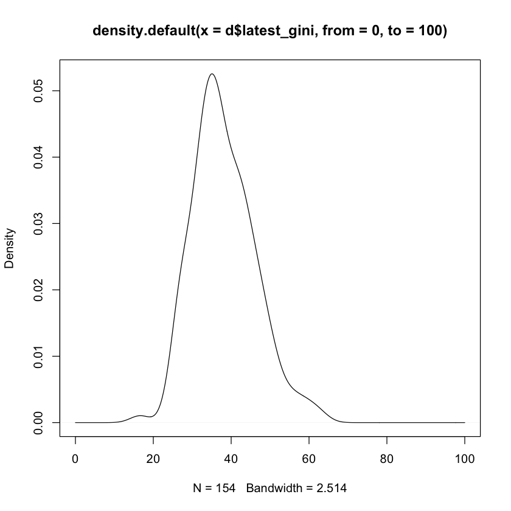

```r
plot(density(d$latest_gini,from=0,to=100))
# alternately:
# dens(d$latest_gini)
```

## 2

The gausian model is $$ G_i\sim N(\mu,\sigma)\\ \mu \sim N(50,20)\\ \sigma \sim U(0,25) $$

```r
m1 <- alist(
    latest_gini ~ dnorm(mu,sigma),
    mu ~ dnorm(50,20),
    sigma ~ dunif(0,25)
)
fit1 <- map(m1,data=d)
precis(fit1,prob=.9)
```

```
       Mean StdDev  5.0% 95.0%
mu    38.17   0.64 37.12 39.21
sigma  7.91   0.45  7.17  8.65
```

The posterior distribution for $\mu$ has a mean of about 38.17, and a 90% credible interval from about 37.12 to 39.21. The posterior distribution for $\sigma$ has a mean of about 7.91, and a 90% credible interval from about 7.17 to 8.65. Together, these results tell us that the average gini index predicted by our model is just below 40 with a spread of about 15 points in either direction. This agrees with the inexact results from question 1.

## 3

The updated model with `colonized` as a covariate is $$ G_i\sim N(\mu,\sigma)\\ \mu = \alpha + \beta_cC_i\\ \alpha \sim N(50,20)\\ \beta_c \sim N(0,20)\\ \sigma \sim U(0,25) $$

```r
m2 <- alist(
    latest_gini ~ dnorm(mu,sigma),
    mu <- a + bc*colonized,
    a ~ dnorm(50,20),
    bc ~ dnorm(0,20),
    sigma ~ dunif(0,25)
)
fit2 <- map(m2,data=d)
precis(fit2,prob=.9)
```

```
       Mean StdDev  5.0% 95.0%
a     34.63   0.96 33.05 36.21
bc     5.73   1.22  3.72  7.74
sigma  7.39   0.42  6.70  8.08
```

This updated model estimates separate means for colonized and never-colonized countries. $\alpha$ is the mean for the never-colonized countries, the posterior for which has a mean of 34.63 and a 90% credible interval from about 33.05 to 36.21. This is lower than the estimate from the last model. The parmeter $\beta$ is difference in means between the colonized and never-colonized countries. The posterior distribution of $\beta$ has a mean of about 5.73 and a 90% credible interval from about 3.72 to 7.74. This means that the model predicts colonized countries will have Gini measures that are, on average, between about 3.72 and 7.74 higher than non-colonized countries. Colonized countries experience more inequality on average than non-colonized countries

## 4

```r
samp2 <- extract.samples(fit2,4000)

# mean uncolonized
mean(samp2$a)
# PI uncolonized
PI(samp2$a,prob=.9)

# mean difference
mean(samp2$b)
# PI difference
PI(samp2$b,prob=.9)
```

34.6007745542813

**5%**

32.9511014463576

**95%**

36.196677568021

5.7681921705743

**5%**

3.77057322160299

**95%**

7.82368628592482

The mean and 90% interval for $\alpha$ (the mean of the never-colonized countries) and $\beta$ (the difference in means) matches nearly exactly with those from the last question.

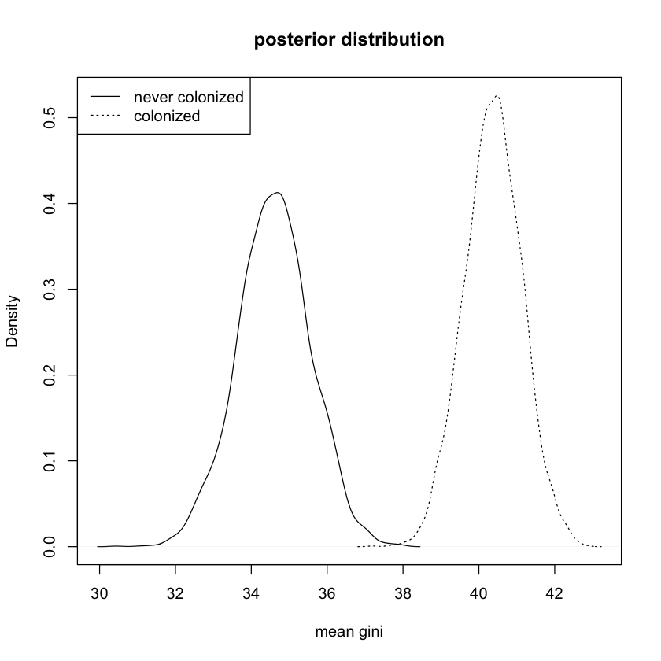

```r
uncolonized_posterior_mean <- density(samp2$a)
colonized_posterior_mean <- density(samp2$a + samp2$b)

xlim <- range(uncolonized_posterior_mean$x,colonized_posterior_mean$x)
ylim <- range(uncolonized_posterior_mean$y,colonized_posterior_mean$y)

plot(uncolonized_posterior_mean,xlim=xlim,ylim=ylim,main='posterior distribution',xlab='mean gini')
lines(colonized_posterior_mean,lty=3)
legend('topleft',lty=c(1,3),legend=c('never colonized','colonized'))
```

The densities above show that the posterior distributions of the means for colonized and never-colonized countries are very different. The plot illustrates that the difference in means is indeed about 5.75, and that the confidence in the difference between the means should be very high (almost no overlap between the distributions).

## 5

```r
m3 <- alist(
    latest_gini ~ dnorm(mu,sigma),
    mu <- a + b1*colonized + b2*population_pct_immigrant_2015,
    a ~ dnorm(50,30),
    b1 ~ dnorm(0,30),
    b2 ~ dnorm(0,30),
    sigma ~ dunif(0,25)
)
fit3 <- map(m3,data=d[!is.na(d$population_pct_immigrant_2015),])
precis(fit3)
```

```
       Mean StdDev  5.5% 94.5%
a     36.47   1.09 34.73 38.20
b1     5.16   1.20  3.24  7.08
b2    -0.24   0.08 -0.36 -0.12
sigma  7.16   0.41  6.50  7.81
```